# Ford GoBike System Data

## Introduction

- In this project I will exploratory data analysis on a Ford GoBike System Data, going from simple univariate relationships up through multivariate relationships, Then I will take main findings from exploration and convey them to others through an explanatory analysis.

## Preliminary Wrangling

```python
# import all packages and set plots to be embedded inline
import numpy as np
import pandas as pd
import matplotlib.pyplot as plt
import seaborn as sb

%matplotlib inline
```

### Gather

```python
# load in the dataset into a pandas dataframe
df = pd.read_csv('201904-fordgobike-tripdata.csv')
```

### Assess

```python
#display the dataframe
df
```

|  | duration_sec | start_time | end_time | start_station_id | start_station_name | start_station_latitude | start_station_longitude | end_station_id | end_station_name | end_station_latitude | end_station_longitude | bike_id | user_type | bike_share_for_all_trip |
| --- | --- | --- | --- | --- | --- | --- | --- | --- | --- | --- | --- | --- | --- | --- |
| 0 | 50305 | 2019-04-30 22:33:55.1550 | 2019-05-01 12:32:20.4540 | 368.0 | Myrtle St at Polk St | 37.785434 | -122.419622 | 324.0 | Union Square (Powell St at Post St) | 37.788300 | -122.408531 | 2749 | Subscriber | No |
| 1 | 53725 | 2019-04-30 20:43:41.6320 | 2019-05-01 11:39:06.9170 | 246.0 | Berkeley Civic Center | 37.869060 | -122.270556 | 241.0 | Ashby BART Station | 37.852477 | -122.270213 | 2608 | Customer | No |
| 2 | 78072 | 2019-04-30 10:32:46.4890 | 2019-05-01 08:13:58.9750 | 64.0 | 5th St at Brannan St | 37.776754 | -122.399018 | 64.0 | 5th St at Brannan St | 37.776754 | -122.399018 | 258 | Subscriber | No |
| 3 | 78969 | 2019-04-30 10:00:51.5500 | 2019-05-01 07:57:01.2620 | 67.0 | San Francisco Caltrain Station 2 (Townsend St... | 37.776639 | -122.395526 | 89.0 | Division St at Potrero Ave | 37.769218 | -122.407646 | 1974 | Subscriber | No |
| 4 | 1128 | 2019-04-30 23:59:04.7390 | 2019-05-01 00:17:53.0910 | 124.0 | 19th St at Florida St | 37.760447 | -122.410807 | 5.0 | Powell St BART Station (Market St at 5th St) | 37.783899 | -122.408445 | 877 | Subscriber | No |
| 5 | 1388 | 2019-04-30 23:53:05.9820 | 2019-05-01 00:16:14.3130 | 243.0 | Bancroft Way at College Ave | 37.869360 | -122.254337 | 247.0 | Fulton St at Bancroft Way | 37.867789 | -122.265896 | 3234 | Customer | No |
| 6 | 920 | 2019-04-30 23:57:56.3400 | 2019-05-01 00:13:16.4540 | 202.0 | Washington St at 8th St | 37.800754 | -122.274894 | 220.0 | San Pablo Ave at MLK Jr Way | 37.811351 | -122.273422 | 3262 | Subscriber | Yes |
| 7 | 725 | 2019-04-30 23:56:11.2190 | 2019-05-01 00:08:16.9150 | 44.0 | Civic Center/UN Plaza BART Station (Market St ... | 37.781074 | -122.411738 | 121.0 | Mission Playground | 37.759210 | -122.421339 | 2706 | Customer | No |
| 8 | 488 | 2019-04-30 23:59:00.6600 | 2019-05-01 00:07:08.9750 | 21.0 | Montgomery St BART Station (Market St at 2nd St) | 37.789625 | -122.400811 | 64.0 | 5th St at Brannan St | 37.776754 | -122.399018 | 860 | Subscriber | No |
| 9 | 792 | 2019-04-30 23:53:37.6040 | 2019-05-01 00:06:50.4050 | 28.0 | The Embarcadero at Bryant St | 37.787168 | -122.388098 | 126.0 | Esprit Park | 37.761634 | -122.390648 | 896 | Subscriber | No |
| 10 | 464 | 2019-04-30 23:56:44.3860 | 2019-05-01 00:04:28.9120 | 89.0 | Division St at Potrero Ave | 37.769218 | -122.407646 | 97.0 | 14th St at Mission St | 37.768265 | -122.420110 | 3048 | Subscriber | No |
| 11 | 782 | 2019-04-30 23:50:49.1440 | 2019-05-01 00:03:51.8470 | 311.0 | Paseo De San Antonio at 2nd St | 37.333798 | -121.886943 | 276.0 | Julian St at The Alameda | 37.332233 | -121.912517 | 3426 | Subscriber | Yes |
| 12 | 775 | 2019-04-30 23:49:05.3880 | 2019-05-01 00:02:00.5450 | 86.0 | Market St at Dolores St | 37.769305 | -122.426826 | 321.0 | 5th St at Folsom | 37.780146 | -122.403071 | 2198 | Subscriber | No |
| 13 | 424 | 2019-04-30 23:52:57.4310 | 2019-05-01 00:00:02.2940 | 223.0 | 16th St Mission BART Station 2 | 37.764765 | -122.420091 | 109.0 | 17th St at Valencia St | 37.763316 | -122.421904 | 1113 | Subscriber | No |
| 14 | 496 | 2019-04-30 23:51:34.4960 | 2019-04-30 23:59:51.4210 | 311.0 | Paseo De San Antonio at 2nd St | 37.333798 | -121.886943 | 278.0 | The Alameda at Bush St | 37.331932 | -121.904888 | 1800 | Subscriber | Yes |
| 15 | 1146 | 2019-04-30 23:40:19.5640 | 2019-04-30 23:59:26.3550 | 93.0 | 4th St at Mission Bay Blvd S | 37.770407 | -122.391198 | 104.0 | 4th St at 16th St | 37.767045 | -122.390833 | 1585 | Subscriber | Yes |
| 16 | 316 | 2019-04-30 23:53:38.8750 | 2019-04-30 23:58:55.6040 | 284.0 | Yerba Buena Center for the Arts (Howard St at ... | 37.784872 | -122.400876 | 67.0 | San Francisco Caltrain Station 2 (Townsend St... | 37.776639 | -122.395526 | 1238 | Subscriber | No |
| 17 | 753 | 2019-04-30 23:45:19.1980 | 2019-04-30 23:57:52.8840 | 152.0 | 47th St at San Pablo Ave | 37.835632 | -122.281051 | 351.0 | 10th St at University Ave | 37.869060 | -122.293400 | 3480 | Subscriber | No |
| 18 | 601 | 2019-04-30 23:43:27.4480 | 2019-04-30 23:53:28.4670 | 357.0 | 2nd St at Julian St | 37.341132 | -121.892844 | 310.0 | San Fernando St at 4th St | 37.335885 | -121.885660 | 3118 | Subscriber | Yes |
| 19 | 248 | 2019-04-30 23:47:01.3120 | 2019-04-30 23:51:09.6200 | 11.0 | Davis St at Jackson St | 37.797280 | -122.398436 | 10.0 | Washington St at Kearny St | 37.795393 | -122.404770 | 2047 | Subscriber | No |
| 20 | 267 | 2019-04-30 23:46:17.0060 | 2019-04-30 23:50:44.5620 | 341.0 | Fountain Alley at S 2nd St | 37.336188 | -121.889277 | 357.0 | 2nd St at Julian St | 37.341132 | -121.892844 | 1788 | Subscriber | Yes |
| 21 | 227 | 2019-04-30 23:45:42.1660 | 2019-04-30 23:49:29.2660 | 312.0 | San Jose Diridon Station | 37.329732 | -121.901782 | 314.0 | Santa Clara St at Almaden Blvd | 37.333988 | -121.894902 | 629 | Customer | No |
| 22 | 392 | 2019-04-30 23:38:39.2080 | 2019-04-30 23:45:11.4320 | 73.0 | Pierce St at Haight St | 37.771793 | -122.433708 | 109.0 | 17th St at Valencia St | 37.763316 | -122.421904 | 377 | Subscriber | No |
| 23 | 528 | 2019-04-30 23:35:42.5030 | 2019-04-30 23:44:30.7640 | 338.0 | 13th St at Franklin St | 37.803189 | -122.270579 | 230.0 | 14th St at Mandela Pkwy | 37.810743 | -122.291415 | 3269 | Subscriber | No |
| 24 | 867 | 2019-04-30 23:29:24.4200 | 2019-04-30 23:43:51.9210 | 370.0 | Jones St at Post St | 37.787327 | -122.413278 | 95.0 | Sanchez St at 15th St | 37.766219 | -122.431060 | 2165 | Subscriber | Yes |
| 25 | 472 | 2019-04-30 23:35:33.6740 | 2019-04-30 23:43:25.9420 | 186.0 | Lakeside Dr at 14th St | 37.801319 | -122.262642 | 196.0 | Grand Ave at Perkins St | 37.808894 | -122.256460 | 2880 | Subscriber | No |
| 26 | 142 | 2019-04-30 23:40:38.0530 | 2019-04-30 23:43:01.0520 | 267.0 | Derby St at College Ave | 37.861804 | -122.253569 | 253.0 | Haste St at College Ave | 37.866418 | -122.253799 | 1378 | Subscriber | Yes |
| 27 | 203 | 2019-04-30 23:37:22.0610 | 2019-04-30 23:40:45.6240 | 95.0 | Sanchez St at 15th St | 37.766219 | -122.431060 | 97.0 | 14th St at Mission St | 37.768265 | -122.420110 | 733 | Subscriber | No |
| 28 | 1491 | 2019-04-30 23:15:30.0160 | 2019-04-30 23:40:21.4110 | 16.0 | Steuart St at Market St | 37.794130 | -122.394430 | 355.0 | 23rd St at Tennessee St | 37.755367 | -122.388795 | 2263 | Subscriber | No |
| 29 | 741 | 2019-04-30 23:26:58.6010 | 2019-04-30 23:39:20.0340 | 53.0 | Grove St at Divisadero | 37.775946 | -122.437777 | 383.0 | Golden Gate Ave at Franklin St | 37.780787 | -122.421934 | 2834 | Subscriber | No |
| ... | ... | ... | ... | ... | ... | ... | ... | ... | ... | ... | ... | ... | ... | ... |
| 239081 | 381 | 2019-04-01 00:51:35.5240 | 2019-04-01 00:57:56.7630 | 162.0 | Franklin St at 9th St | 37.800516 | -122.272080 | 186.0 | Lakeside Dr at 14th St | 37.801319 | -122.262642 | 5456 | Subscriber | Yes |
| 239082 | 300 | 2019-04-01 00:51:33.3900 | 2019-04-01 00:56:34.0070 | 78.0 | Folsom St at 9th St | 37.773717 | -122.411647 | 383.0 | Golden Gate Ave at Franklin St | 37.780787 | -122.421934 | 4804 | Subscriber | No |
| 239083 | 481 | 2019-04-01 00:43:59.0460 | 2019-04-01 00:52:00.7090 | 58.0 | Market St at 10th St | 37.776619 | -122.417385 | 81.0 | Berry St at 4th St | 37.775880 | -122.393170 | 6220 | Subscriber | No |
| 239084 | 306 | 2019-04-01 00:43:51.7730 | 2019-04-01 00:48:58.6240 | 84.0 | Duboce Park | 37.769201 | -122.433812 | 71.0 | Broderick St at Oak St | 37.773063 | -122.439078 | 6258 | Customer | No |
| 239085 | 403 | 2019-04-01 00:41:37.0610 | 2019-04-01 00:48:20.3290 | 62.0 | Victoria Manalo Draves Park | 37.777791 | -122.406432 | 383.0 | Golden Gate Ave at Franklin St | 37.780787 | -122.421934 | 4335 | Subscriber | No |
| 239086 | 356 | 2019-04-01 00:38:02.1470 | 2019-04-01 00:43:58.5220 | 93.0 | 4th St at Mission Bay Blvd S | 37.770407 | -122.391198 | 336.0 | Potrero Ave and Mariposa St | 37.763281 | -122.407377 | 5470 | Subscriber | No |
| 239087 | 353 | 2019-04-01 00:37:22.7060 | 2019-04-01 00:43:16.4440 | 255.0 | Virginia St at Shattuck Ave | 37.876573 | -122.269528 | 243.0 | Bancroft Way at College Ave | 37.869360 | -122.254337 | 4724 | Subscriber | No |
| 239088 | 644 | 2019-04-01 00:32:31.8610 | 2019-04-01 00:43:16.1100 | 324.0 | Union Square (Powell St at Post St) | 37.788300 | -122.408531 | 21.0 | Montgomery St BART Station (Market St at 2nd St) | 37.789625 | -122.400811 | 2683 | Subscriber | No |
| 239089 | 163 | 2019-04-01 00:40:33.0100 | 2019-04-01 00:43:16.0860 | 19.0 | Post St at Kearny St | 37.788975 | -122.403452 | 21.0 | Montgomery St BART Station (Market St at 2nd St) | 37.789625 | -122.400811 | 1850 | Customer | No |
| 239090 | 235 | 2019-04-01 00:36:07.8390 | 2019-04-01 00:40:03.1410 | 58.0 | Market St at 10th St | 37.776619 | -122.417385 | 58.0 | Market St at 10th St | 37.776619 | -122.417385 | 5870 | Subscriber | No |
| 239091 | 209 | 2019-04-01 00:35:43.7490 | 2019-04-01 00:39:13.7120 | 324.0 | Union Square (Powell St at Post St) | 37.788300 | -122.408531 | 19.0 | Post St at Kearny St | 37.788975 | -122.403452 | 1850 | Customer | No |
| 239092 | 388 | 2019-04-01 00:32:43.7740 | 2019-04-01 00:39:12.6000 | 310.0 | San Fernando St at 4th St | 37.335885 | -121.885660 | 305.0 | Ryland Park | 37.342725 | -121.895617 | 5634 | Subscriber | Yes |
| 239093 | 883 | 2019-04-01 00:22:56.6840 | 2019-04-01 00:37:39.8730 | 6.0 | The Embarcadero at Sansome St | 37.804770 | -122.403234 | 37.0 | 2nd St at Folsom St | 37.785377 | -122.396906 | 1836 | Customer | No |
| 239094 | 314 | 2019-04-01 00:30:12.7130 | 2019-04-01 00:35:26.8790 | 77.0 | 11th St at Natoma St | 37.773507 | -122.416040 | 62.0 | Victoria Manalo Draves Park | 37.777791 | -122.406432 | 4972 | Subscriber | No |
| 239095 | 1503 | 2019-04-01 00:08:58.1150 | 2019-04-01 00:34:01.2680 | 8.0 | The Embarcadero at Vallejo St | 37.799953 | -122.398525 | 350.0 | 8th St at Brannan St | 37.771431 | -122.405787 | 6112 | Subscriber | No |
| 239096 | 1447 | 2019-04-01 00:07:53.8860 | 2019-04-01 00:32:01.6490 | 14.0 | Clay St at Battery St | 37.795001 | -122.399970 | 133.0 | Valencia St at 22nd St | 37.755213 | -122.420975 | 1110 | Subscriber | No |
| 239097 | 212 | 2019-04-01 00:26:28.7270 | 2019-04-01 00:30:01.5600 | 34.0 | Father Alfred E Boeddeker Park | 37.783988 | -122.412408 | 3.0 | Powell St BART Station (Market St at 4th St) | 37.786375 | -122.404904 | 3434 | Subscriber | Yes |
| 239098 | 135 | 2019-04-01 00:25:45.1930 | 2019-04-01 00:28:00.5190 | 311.0 | Paseo De San Antonio at 2nd St | 37.333798 | -121.886943 | 327.0 | 5th St at San Salvador St | 37.332039 | -121.881766 | 3967 | Subscriber | Yes |
| 239099 | 159 | 2019-04-01 00:24:50.6840 | 2019-04-01 00:27:30.4890 | 98.0 | Valencia St at 16th St | 37.765052 | -122.421866 | 122.0 | 19th St at Mission St | 37.760299 | -122.418892 | 2260 | Subscriber | Yes |
| 239100 | 423 | 2019-04-01 00:20:25.4900 | 2019-04-01 00:27:28.7290 | 62.0 | Victoria Manalo Draves Park | 37.777791 | -122.406432 | 77.0 | 11th St at Natoma St | 37.773507 | -122.416040 | 4812 | Subscriber | No |
| 239101 | 197 | 2019-04-01 00:23:21.0390 | 2019-04-01 00:26:38.3840 | 266.0 | Parker St at Fulton St | 37.862464 | -122.264791 | 252.0 | Channing Way at Shattuck Ave | 37.865847 | -122.267443 | 6425 | Subscriber | No |
| 239102 | 914 | 2019-04-01 00:11:07.6120 | 2019-04-01 00:26:21.7070 | 142.0 | Guerrero Park | 37.745739 | -122.422140 | 63.0 | Bryant St at 6th St | 37.775910 | -122.402575 | 5487 | Subscriber | No |
| 239103 | 869 | 2019-04-01 00:08:19.0010 | 2019-04-01 00:22:48.8640 | 81.0 | Berry St at 4th St | 37.775880 | -122.393170 | 81.0 | Berry St at 4th St | 37.775880 | -122.393170 | 5910 | Customer | No |
| 239104 | 396 | 2019-04-01 00:14:37.9600 | 2019-04-01 00:21:14.4020 | 43.0 | San Francisco Public Library (Grove St at Hyde... | 37.778768 | -122.415929 | 365.0 | Turk St at Fillmore St | 37.780450 | -122.431946 | 6448 | Subscriber | No |
| 239105 | 421 | 2019-04-01 00:11:05.2760 | 2019-04-01 00:18:06.8220 | 280.0 | San Fernando St at 7th St | 37.337122 | -121.883215 | 305.0 | Ryland Park | 37.342725 | -121.895617 | 6274 | Subscriber | Yes |
| 239106 | 184 | 2019-04-01 00:09:17.5660 | 2019-04-01 00:12:22.5170 | 133.0 | Valencia St at 22nd St | 37.755213 | -122.420975 | 132.0 | 24th St at Chattanooga St | 37.751819 | -122.426614 | 6430 | Subscriber | No |
| 239107 | 539 | 2019-04-01 00:03:02.5730 | 2019-04-01 00:12:02.0670 | 78.0 | Folsom St at 9th St | 37.773717 | -122.411647 | 77.0 | 11th St at Natoma St | 37.773507 | -122.416040 | 4972 | Subscriber | Yes |
| 239108 | 292 | 2019-04-01 00:06:04.2370 | 2019-04-01 00:10:56.9850 | 243.0 | Bancroft Way at College Ave | 37.869360 | -122.254337 | 269.0 | Telegraph Ave at Carleton St | 37.862320 | -122.258801 | 3415 | Subscriber | Yes |
| 239109 | 471 | 2019-04-01 00:01:38.4110 | 2019-04-01 00:09:29.9650 | 370.0 | Jones St at Post St | 37.787327 | -122.413278 | 43.0 | San Francisco Public Library (Grove St at Hyde... | 37.778768 | -122.415929 | 5018 | Subscriber | Yes |
| 239110 | 356 | 2019-04-01 00:00:28.7290 | 2019-04-01 00:06:25.0650 | 14.0 | Clay St at Battery St | 37.795001 | -122.399970 | 371.0 | Lombard St at Columbus Ave | 37.802746 | -122.413579 | 5956 | Subscriber | No |

239111 rows × 14 columns

```python
# view dimenesion of dataset
df.shape
```

```
(239111, 14)
```

```python
# check if there is a duplicated rows
sum(df.duplicated())
```

```
0
```

```python
# view missing value count for each feature in dataset
df.isnull().sum()
```

```
duration_sec                0
start_time                  0
end_time                    0
start_station_id           64
start_station_name         64
start_station_latitude      0
start_station_longitude     0
end_station_id             64
end_station_name           64
end_station_latitude        0
end_station_longitude       0
bike_id                     0
user_type                   0
bike_share_for_all_trip     0
dtype: int64
```

```python
#display a basic summary of the dataframe
df.info()
```

```
<class 'pandas.core.frame.DataFrame'>
RangeIndex: 239111 entries, 0 to 239110
Data columns (total 14 columns):
duration_sec               239111 non-null int64
start_time                 239111 non-null object
end_time                   239111 non-null object
start_station_id           239047 non-null float64
start_station_name         239047 non-null object
start_station_latitude     239111 non-null float64
start_station_longitude    239111 non-null float64
end_station_id             239047 non-null float64
end_station_name           239047 non-null object
end_station_latitude       239111 non-null float64
end_station_longitude      239111 non-null float64
bike_id                    239111 non-null int64
user_type                  239111 non-null object
bike_share_for_all_trip    239111 non-null object
dtypes: float64(6), int64(2), object(6)
memory usage: 25.5+ MB
```

```python
#display the entry count for the bike_share_for_all_trip column
df['bike_share_for_all_trip'].value_counts()
```

```
No     218470
Yes     20641
Name: bike_share_for_all_trip, dtype: int64
```

```python
#display the entry count for the user_type column
df['user_type'].value_counts()
```

```
Subscriber    203197
Customer       35914
Name: user_type, dtype: int64
```

#### Quality Issues:

- Missing values
- start_time and end_time shoud be datetime
- start_station_id, end_station_id and bike_id shoud be object
- user_type and bike_share_for_all_trip can be set to category

#### Tidiness Issues:

- add columns start_date, start_month, start_day_of_week, start_hour

### Clean

```python
# Make a copy of the dataframe
df_clean = df.copy()
```

#### Define

- Remove rows that doesn't have station id

#### Code

```python
# Remove rows that does not have station id
df_clean = df_clean[df_clean['start_station_id'].isnull() == False]
```

#### Test

```python
# view missing value count for each feature in dataset
df_clean.isnull().sum()
```

```
duration_sec               0
start_time                 0
end_time                   0
start_station_id           0
start_station_name         0
start_station_latitude     0
start_station_longitude    0
end_station_id             0
end_station_name           0
end_station_latitude       0
end_station_longitude      0
bike_id                    0
user_type                  0
bike_share_for_all_trip    0
dtype: int64
```

#### Define

- Change the datatypes of columns start_station_id, end_station_id and bike_id to object and the datatypes of columns start_time and end_time to datetime

#### Code

```python
# Change the datatype
df_clean = pd.read_csv('201904-fordgobike-tripdata.csv',
                dtype={'start_station_id': 'object',
                      'end_station_id': 'object',
                      'bike_id': 'object'},
                parse_dates = ['start_time','end_time'])
```

#### Define

- Change the datatypes of columns user type and bike_share_for_all_trip to category

#### Code

```python
# set user type and bike_share_for_all_trip to category
df_clean.user_type = df_clean.user_type.astype('category')
df_clean.bike_share_for_all_trip = df_clean.bike_share_for_all_trip.astype('category')
```

#### Test

```python
df_clean.dtypes
```

```
duration_sec                        int64
start_time                 datetime64[ns]
end_time                   datetime64[ns]
start_station_id                   object
start_station_name                 object
start_station_latitude            float64
start_station_longitude           float64
end_station_id                     object
end_station_name                   object
end_station_latitude              float64
end_station_longitude             float64
bike_id                            object
user_type                        category
bike_share_for_all_trip          category
dtype: object
```

#### Define

- I'll add columns start_date, start_month, start_day_of_week, start_hour

#### Code

```python
df_clean['start_date'] = df_clean.start_time.dt.strftime('%Y-%m-%d')
df_clean['start_month'] = df_clean.start_time.dt.strftime('%B')
df_clean['start_day_of_week'] = df_clean.start_time.dt.strftime('%A')
df_clean['start_hour'] = df_clean.start_time.dt.strftime('%H')
```

#### Test

```python
df_clean.sample()
```

|  | duration_sec | start_time | end_time | start_station_id | start_station_name | start_station_latitude | start_station_longitude | end_station_id | end_station_name | end_station_latitude | end_station_longitude | bike_id | user_type | bike_share_for_all_trip | start_date | start_month | start_day_of_week | start_hour |
| --- | --- | --- | --- | --- | --- | --- | --- | --- | --- | --- | --- | --- | --- | --- | --- | --- | --- | --- |
| 65254 | 170 | 2019-04-20 16:49:33.429 | 2019-04-20 16:52:24.346 | 96 | Dolores St at 15th St | 37.76621 | -122.426614 | 120 | Mission Dolores Park | 37.76142 | -122.426435 | 3348 | Subscriber | No | 2019-04-20 | April | Saturday | 16 |

## Visualization

```python
df_clean
```

|  | duration_sec | start_time | end_time | start_station_id | start_station_name | start_station_latitude | start_station_longitude | end_station_id | end_station_name | end_station_latitude | end_station_longitude | bike_id | user_type | bike_share_for_all_trip | start_date | start_month | start_day_of_week | start_hour |
| --- | --- | --- | --- | --- | --- | --- | --- | --- | --- | --- | --- | --- | --- | --- | --- | --- | --- | --- |
| 0 | 50305 | 2019-04-30 22:33:55.155 | 2019-05-01 12:32:20.454 | 368 | Myrtle St at Polk St | 37.785434 | -122.419622 | 324 | Union Square (Powell St at Post St) | 37.788300 | -122.408531 | 2749 | Subscriber | No | 2019-04-30 | April | Tuesday | 22 |
| 1 | 53725 | 2019-04-30 20:43:41.632 | 2019-05-01 11:39:06.917 | 246 | Berkeley Civic Center | 37.869060 | -122.270556 | 241 | Ashby BART Station | 37.852477 | -122.270213 | 2608 | Customer | No | 2019-04-30 | April | Tuesday | 20 |
| 2 | 78072 | 2019-04-30 10:32:46.489 | 2019-05-01 08:13:58.975 | 64 | 5th St at Brannan St | 37.776754 | -122.399018 | 64 | 5th St at Brannan St | 37.776754 | -122.399018 | 258 | Subscriber | No | 2019-04-30 | April | Tuesday | 10 |
| 3 | 78969 | 2019-04-30 10:00:51.550 | 2019-05-01 07:57:01.262 | 67 | San Francisco Caltrain Station 2 (Townsend St... | 37.776639 | -122.395526 | 89 | Division St at Potrero Ave | 37.769218 | -122.407646 | 1974 | Subscriber | No | 2019-04-30 | April | Tuesday | 10 |
| 4 | 1128 | 2019-04-30 23:59:04.739 | 2019-05-01 00:17:53.091 | 124 | 19th St at Florida St | 37.760447 | -122.410807 | 5 | Powell St BART Station (Market St at 5th St) | 37.783899 | -122.408445 | 877 | Subscriber | No | 2019-04-30 | April | Tuesday | 23 |
| 5 | 1388 | 2019-04-30 23:53:05.982 | 2019-05-01 00:16:14.313 | 243 | Bancroft Way at College Ave | 37.869360 | -122.254337 | 247 | Fulton St at Bancroft Way | 37.867789 | -122.265896 | 3234 | Customer | No | 2019-04-30 | April | Tuesday | 23 |
| 6 | 920 | 2019-04-30 23:57:56.340 | 2019-05-01 00:13:16.454 | 202 | Washington St at 8th St | 37.800754 | -122.274894 | 220 | San Pablo Ave at MLK Jr Way | 37.811351 | -122.273422 | 3262 | Subscriber | Yes | 2019-04-30 | April | Tuesday | 23 |
| 7 | 725 | 2019-04-30 23:56:11.219 | 2019-05-01 00:08:16.915 | 44 | Civic Center/UN Plaza BART Station (Market St ... | 37.781074 | -122.411738 | 121 | Mission Playground | 37.759210 | -122.421339 | 2706 | Customer | No | 2019-04-30 | April | Tuesday | 23 |
| 8 | 488 | 2019-04-30 23:59:00.660 | 2019-05-01 00:07:08.975 | 21 | Montgomery St BART Station (Market St at 2nd St) | 37.789625 | -122.400811 | 64 | 5th St at Brannan St | 37.776754 | -122.399018 | 860 | Subscriber | No | 2019-04-30 | April | Tuesday | 23 |
| 9 | 792 | 2019-04-30 23:53:37.604 | 2019-05-01 00:06:50.405 | 28 | The Embarcadero at Bryant St | 37.787168 | -122.388098 | 126 | Esprit Park | 37.761634 | -122.390648 | 896 | Subscriber | No | 2019-04-30 | April | Tuesday | 23 |
| 10 | 464 | 2019-04-30 23:56:44.386 | 2019-05-01 00:04:28.912 | 89 | Division St at Potrero Ave | 37.769218 | -122.407646 | 97 | 14th St at Mission St | 37.768265 | -122.420110 | 3048 | Subscriber | No | 2019-04-30 | April | Tuesday | 23 |
| 11 | 782 | 2019-04-30 23:50:49.144 | 2019-05-01 00:03:51.847 | 311 | Paseo De San Antonio at 2nd St | 37.333798 | -121.886943 | 276 | Julian St at The Alameda | 37.332233 | -121.912517 | 3426 | Subscriber | Yes | 2019-04-30 | April | Tuesday | 23 |
| 12 | 775 | 2019-04-30 23:49:05.388 | 2019-05-01 00:02:00.545 | 86 | Market St at Dolores St | 37.769305 | -122.426826 | 321 | 5th St at Folsom | 37.780146 | -122.403071 | 2198 | Subscriber | No | 2019-04-30 | April | Tuesday | 23 |
| 13 | 424 | 2019-04-30 23:52:57.431 | 2019-05-01 00:00:02.294 | 223 | 16th St Mission BART Station 2 | 37.764765 | -122.420091 | 109 | 17th St at Valencia St | 37.763316 | -122.421904 | 1113 | Subscriber | No | 2019-04-30 | April | Tuesday | 23 |
| 14 | 496 | 2019-04-30 23:51:34.496 | 2019-04-30 23:59:51.421 | 311 | Paseo De San Antonio at 2nd St | 37.333798 | -121.886943 | 278 | The Alameda at Bush St | 37.331932 | -121.904888 | 1800 | Subscriber | Yes | 2019-04-30 | April | Tuesday | 23 |
| 15 | 1146 | 2019-04-30 23:40:19.564 | 2019-04-30 23:59:26.355 | 93 | 4th St at Mission Bay Blvd S | 37.770407 | -122.391198 | 104 | 4th St at 16th St | 37.767045 | -122.390833 | 1585 | Subscriber | Yes | 2019-04-30 | April | Tuesday | 23 |
| 16 | 316 | 2019-04-30 23:53:38.875 | 2019-04-30 23:58:55.604 | 284 | Yerba Buena Center for the Arts (Howard St at ... | 37.784872 | -122.400876 | 67 | San Francisco Caltrain Station 2 (Townsend St... | 37.776639 | -122.395526 | 1238 | Subscriber | No | 2019-04-30 | April | Tuesday | 23 |
| 17 | 753 | 2019-04-30 23:45:19.198 | 2019-04-30 23:57:52.884 | 152 | 47th St at San Pablo Ave | 37.835632 | -122.281051 | 351 | 10th St at University Ave | 37.869060 | -122.293400 | 3480 | Subscriber | No | 2019-04-30 | April | Tuesday | 23 |
| 18 | 601 | 2019-04-30 23:43:27.448 | 2019-04-30 23:53:28.467 | 357 | 2nd St at Julian St | 37.341132 | -121.892844 | 310 | San Fernando St at 4th St | 37.335885 | -121.885660 | 3118 | Subscriber | Yes | 2019-04-30 | April | Tuesday | 23 |
| 19 | 248 | 2019-04-30 23:47:01.312 | 2019-04-30 23:51:09.620 | 11 | Davis St at Jackson St | 37.797280 | -122.398436 | 10 | Washington St at Kearny St | 37.795393 | -122.404770 | 2047 | Subscriber | No | 2019-04-30 | April | Tuesday | 23 |
| 20 | 267 | 2019-04-30 23:46:17.006 | 2019-04-30 23:50:44.562 | 341 | Fountain Alley at S 2nd St | 37.336188 | -121.889277 | 357 | 2nd St at Julian St | 37.341132 | -121.892844 | 1788 | Subscriber | Yes | 2019-04-30 | April | Tuesday | 23 |
| 21 | 227 | 2019-04-30 23:45:42.166 | 2019-04-30 23:49:29.266 | 312 | San Jose Diridon Station | 37.329732 | -121.901782 | 314 | Santa Clara St at Almaden Blvd | 37.333988 | -121.894902 | 629 | Customer | No | 2019-04-30 | April | Tuesday | 23 |
| 22 | 392 | 2019-04-30 23:38:39.208 | 2019-04-30 23:45:11.432 | 73 | Pierce St at Haight St | 37.771793 | -122.433708 | 109 | 17th St at Valencia St | 37.763316 | -122.421904 | 377 | Subscriber | No | 2019-04-30 | April | Tuesday | 23 |
| 23 | 528 | 2019-04-30 23:35:42.503 | 2019-04-30 23:44:30.764 | 338 | 13th St at Franklin St | 37.803189 | -122.270579 | 230 | 14th St at Mandela Pkwy | 37.810743 | -122.291415 | 3269 | Subscriber | No | 2019-04-30 | April | Tuesday | 23 |
| 24 | 867 | 2019-04-30 23:29:24.420 | 2019-04-30 23:43:51.921 | 370 | Jones St at Post St | 37.787327 | -122.413278 | 95 | Sanchez St at 15th St | 37.766219 | -122.431060 | 2165 | Subscriber | Yes | 2019-04-30 | April | Tuesday | 23 |
| 25 | 472 | 2019-04-30 23:35:33.674 | 2019-04-30 23:43:25.942 | 186 | Lakeside Dr at 14th St | 37.801319 | -122.262642 | 196 | Grand Ave at Perkins St | 37.808894 | -122.256460 | 2880 | Subscriber | No | 2019-04-30 | April | Tuesday | 23 |
| 26 | 142 | 2019-04-30 23:40:38.053 | 2019-04-30 23:43:01.052 | 267 | Derby St at College Ave | 37.861804 | -122.253569 | 253 | Haste St at College Ave | 37.866418 | -122.253799 | 1378 | Subscriber | Yes | 2019-04-30 | April | Tuesday | 23 |
| 27 | 203 | 2019-04-30 23:37:22.061 | 2019-04-30 23:40:45.624 | 95 | Sanchez St at 15th St | 37.766219 | -122.431060 | 97 | 14th St at Mission St | 37.768265 | -122.420110 | 733 | Subscriber | No | 2019-04-30 | April | Tuesday | 23 |
| 28 | 1491 | 2019-04-30 23:15:30.016 | 2019-04-30 23:40:21.411 | 16 | Steuart St at Market St | 37.794130 | -122.394430 | 355 | 23rd St at Tennessee St | 37.755367 | -122.388795 | 2263 | Subscriber | No | 2019-04-30 | April | Tuesday | 23 |
| 29 | 741 | 2019-04-30 23:26:58.601 | 2019-04-30 23:39:20.034 | 53 | Grove St at Divisadero | 37.775946 | -122.437777 | 383 | Golden Gate Ave at Franklin St | 37.780787 | -122.421934 | 2834 | Subscriber | No | 2019-04-30 | April | Tuesday | 23 |
| ... | ... | ... | ... | ... | ... | ... | ... | ... | ... | ... | ... | ... | ... | ... | ... | ... | ... | ... |
| 239081 | 381 | 2019-04-01 00:51:35.524 | 2019-04-01 00:57:56.763 | 162 | Franklin St at 9th St | 37.800516 | -122.272080 | 186 | Lakeside Dr at 14th St | 37.801319 | -122.262642 | 5456 | Subscriber | Yes | 2019-04-01 | April | Monday | 00 |
| 239082 | 300 | 2019-04-01 00:51:33.390 | 2019-04-01 00:56:34.007 | 78 | Folsom St at 9th St | 37.773717 | -122.411647 | 383 | Golden Gate Ave at Franklin St | 37.780787 | -122.421934 | 4804 | Subscriber | No | 2019-04-01 | April | Monday | 00 |
| 239083 | 481 | 2019-04-01 00:43:59.046 | 2019-04-01 00:52:00.709 | 58 | Market St at 10th St | 37.776619 | -122.417385 | 81 | Berry St at 4th St | 37.775880 | -122.393170 | 6220 | Subscriber | No | 2019-04-01 | April | Monday | 00 |
| 239084 | 306 | 2019-04-01 00:43:51.773 | 2019-04-01 00:48:58.624 | 84 | Duboce Park | 37.769201 | -122.433812 | 71 | Broderick St at Oak St | 37.773063 | -122.439078 | 6258 | Customer | No | 2019-04-01 | April | Monday | 00 |
| 239085 | 403 | 2019-04-01 00:41:37.061 | 2019-04-01 00:48:20.329 | 62 | Victoria Manalo Draves Park | 37.777791 | -122.406432 | 383 | Golden Gate Ave at Franklin St | 37.780787 | -122.421934 | 4335 | Subscriber | No | 2019-04-01 | April | Monday | 00 |
| 239086 | 356 | 2019-04-01 00:38:02.147 | 2019-04-01 00:43:58.522 | 93 | 4th St at Mission Bay Blvd S | 37.770407 | -122.391198 | 336 | Potrero Ave and Mariposa St | 37.763281 | -122.407377 | 5470 | Subscriber | No | 2019-04-01 | April | Monday | 00 |
| 239087 | 353 | 2019-04-01 00:37:22.706 | 2019-04-01 00:43:16.444 | 255 | Virginia St at Shattuck Ave | 37.876573 | -122.269528 | 243 | Bancroft Way at College Ave | 37.869360 | -122.254337 | 4724 | Subscriber | No | 2019-04-01 | April | Monday | 00 |
| 239088 | 644 | 2019-04-01 00:32:31.861 | 2019-04-01 00:43:16.110 | 324 | Union Square (Powell St at Post St) | 37.788300 | -122.408531 | 21 | Montgomery St BART Station (Market St at 2nd St) | 37.789625 | -122.400811 | 2683 | Subscriber | No | 2019-04-01 | April | Monday | 00 |
| 239089 | 163 | 2019-04-01 00:40:33.010 | 2019-04-01 00:43:16.086 | 19 | Post St at Kearny St | 37.788975 | -122.403452 | 21 | Montgomery St BART Station (Market St at 2nd St) | 37.789625 | -122.400811 | 1850 | Customer | No | 2019-04-01 | April | Monday | 00 |
| 239090 | 235 | 2019-04-01 00:36:07.839 | 2019-04-01 00:40:03.141 | 58 | Market St at 10th St | 37.776619 | -122.417385 | 58 | Market St at 10th St | 37.776619 | -122.417385 | 5870 | Subscriber | No | 2019-04-01 | April | Monday | 00 |
| 239091 | 209 | 2019-04-01 00:35:43.749 | 2019-04-01 00:39:13.712 | 324 | Union Square (Powell St at Post St) | 37.788300 | -122.408531 | 19 | Post St at Kearny St | 37.788975 | -122.403452 | 1850 | Customer | No | 2019-04-01 | April | Monday | 00 |
| 239092 | 388 | 2019-04-01 00:32:43.774 | 2019-04-01 00:39:12.600 | 310 | San Fernando St at 4th St | 37.335885 | -121.885660 | 305 | Ryland Park | 37.342725 | -121.895617 | 5634 | Subscriber | Yes | 2019-04-01 | April | Monday | 00 |
| 239093 | 883 | 2019-04-01 00:22:56.684 | 2019-04-01 00:37:39.873 | 6 | The Embarcadero at Sansome St | 37.804770 | -122.403234 | 37 | 2nd St at Folsom St | 37.785377 | -122.396906 | 1836 | Customer | No | 2019-04-01 | April | Monday | 00 |
| 239094 | 314 | 2019-04-01 00:30:12.713 | 2019-04-01 00:35:26.879 | 77 | 11th St at Natoma St | 37.773507 | -122.416040 | 62 | Victoria Manalo Draves Park | 37.777791 | -122.406432 | 4972 | Subscriber | No | 2019-04-01 | April | Monday | 00 |
| 239095 | 1503 | 2019-04-01 00:08:58.115 | 2019-04-01 00:34:01.268 | 8 | The Embarcadero at Vallejo St | 37.799953 | -122.398525 | 350 | 8th St at Brannan St | 37.771431 | -122.405787 | 6112 | Subscriber | No | 2019-04-01 | April | Monday | 00 |
| 239096 | 1447 | 2019-04-01 00:07:53.886 | 2019-04-01 00:32:01.649 | 14 | Clay St at Battery St | 37.795001 | -122.399970 | 133 | Valencia St at 22nd St | 37.755213 | -122.420975 | 1110 | Subscriber | No | 2019-04-01 | April | Monday | 00 |
| 239097 | 212 | 2019-04-01 00:26:28.727 | 2019-04-01 00:30:01.560 | 34 | Father Alfred E Boeddeker Park | 37.783988 | -122.412408 | 3 | Powell St BART Station (Market St at 4th St) | 37.786375 | -122.404904 | 3434 | Subscriber | Yes | 2019-04-01 | April | Monday | 00 |
| 239098 | 135 | 2019-04-01 00:25:45.193 | 2019-04-01 00:28:00.519 | 311 | Paseo De San Antonio at 2nd St | 37.333798 | -121.886943 | 327 | 5th St at San Salvador St | 37.332039 | -121.881766 | 3967 | Subscriber | Yes | 2019-04-01 | April | Monday | 00 |
| 239099 | 159 | 2019-04-01 00:24:50.684 | 2019-04-01 00:27:30.489 | 98 | Valencia St at 16th St | 37.765052 | -122.421866 | 122 | 19th St at Mission St | 37.760299 | -122.418892 | 2260 | Subscriber | Yes | 2019-04-01 | April | Monday | 00 |
| 239100 | 423 | 2019-04-01 00:20:25.490 | 2019-04-01 00:27:28.729 | 62 | Victoria Manalo Draves Park | 37.777791 | -122.406432 | 77 | 11th St at Natoma St | 37.773507 | -122.416040 | 4812 | Subscriber | No | 2019-04-01 | April | Monday | 00 |
| 239101 | 197 | 2019-04-01 00:23:21.039 | 2019-04-01 00:26:38.384 | 266 | Parker St at Fulton St | 37.862464 | -122.264791 | 252 | Channing Way at Shattuck Ave | 37.865847 | -122.267443 | 6425 | Subscriber | No | 2019-04-01 | April | Monday | 00 |
| 239102 | 914 | 2019-04-01 00:11:07.612 | 2019-04-01 00:26:21.707 | 142 | Guerrero Park | 37.745739 | -122.422140 | 63 | Bryant St at 6th St | 37.775910 | -122.402575 | 5487 | Subscriber | No | 2019-04-01 | April | Monday | 00 |
| 239103 | 869 | 2019-04-01 00:08:19.001 | 2019-04-01 00:22:48.864 | 81 | Berry St at 4th St | 37.775880 | -122.393170 | 81 | Berry St at 4th St | 37.775880 | -122.393170 | 5910 | Customer | No | 2019-04-01 | April | Monday | 00 |
| 239104 | 396 | 2019-04-01 00:14:37.960 | 2019-04-01 00:21:14.402 | 43 | San Francisco Public Library (Grove St at Hyde... | 37.778768 | -122.415929 | 365 | Turk St at Fillmore St | 37.780450 | -122.431946 | 6448 | Subscriber | No | 2019-04-01 | April | Monday | 00 |
| 239105 | 421 | 2019-04-01 00:11:05.276 | 2019-04-01 00:18:06.822 | 280 | San Fernando St at 7th St | 37.337122 | -121.883215 | 305 | Ryland Park | 37.342725 | -121.895617 | 6274 | Subscriber | Yes | 2019-04-01 | April | Monday | 00 |
| 239106 | 184 | 2019-04-01 00:09:17.566 | 2019-04-01 00:12:22.517 | 133 | Valencia St at 22nd St | 37.755213 | -122.420975 | 132 | 24th St at Chattanooga St | 37.751819 | -122.426614 | 6430 | Subscriber | No | 2019-04-01 | April | Monday | 00 |
| 239107 | 539 | 2019-04-01 00:03:02.573 | 2019-04-01 00:12:02.067 | 78 | Folsom St at 9th St | 37.773717 | -122.411647 | 77 | 11th St at Natoma St | 37.773507 | -122.416040 | 4972 | Subscriber | Yes | 2019-04-01 | April | Monday | 00 |
| 239108 | 292 | 2019-04-01 00:06:04.237 | 2019-04-01 00:10:56.985 | 243 | Bancroft Way at College Ave | 37.869360 | -122.254337 | 269 | Telegraph Ave at Carleton St | 37.862320 | -122.258801 | 3415 | Subscriber | Yes | 2019-04-01 | April | Monday | 00 |
| 239109 | 471 | 2019-04-01 00:01:38.411 | 2019-04-01 00:09:29.965 | 370 | Jones St at Post St | 37.787327 | -122.413278 | 43 | San Francisco Public Library (Grove St at Hyde... | 37.778768 | -122.415929 | 5018 | Subscriber | Yes | 2019-04-01 | April | Monday | 00 |
| 239110 | 356 | 2019-04-01 00:00:28.729 | 2019-04-01 00:06:25.065 | 14 | Clay St at Battery St | 37.795001 | -122.399970 | 371 | Lombard St at Columbus Ave | 37.802746 | -122.413579 | 5956 | Subscriber | No | 2019-04-01 | April | Monday | 00 |

239111 rows × 18 columns

```python
df_clean.info()
```

```
<class 'pandas.core.frame.DataFrame'>
RangeIndex: 239111 entries, 0 to 239110
Data columns (total 18 columns):
duration_sec               239111 non-null int64
start_time                 239111 non-null datetime64[ns]
end_time                   239111 non-null datetime64[ns]
start_station_id           239047 non-null object
start_station_name         239047 non-null object
start_station_latitude     239111 non-null float64
start_station_longitude    239111 non-null float64
end_station_id             239047 non-null object
end_station_name           239047 non-null object
end_station_latitude       239111 non-null float64
end_station_longitude      239111 non-null float64
bike_id                    239111 non-null object
user_type                  239111 non-null category
bike_share_for_all_trip    239111 non-null category
start_date                 239111 non-null object
start_month                239111 non-null object
start_day_of_week          239111 non-null object
start_hour                 239111 non-null object
dtypes: category(2), datetime64[ns](2), float64(4), int64(1), object(9)
memory usage: 29.6+ MB
```

### What is the structure of your dataset?

- trip duration in second
- start and end time for the bike rides (start_date, start_month, start_day_of_week, start_hour)
- stations, start and end stations id, name, latitude, and longitude
- the bike id
- user type, Subscriber or Customer
- bike share for all trip, yes or no

### What is/are the main feature(s) of interest in your dataset?

```
   I'm most interested in investigate the trip duration.
```

### What features in the dataset do you think will help support your investigation into your feature(s) of interest?

- user_type
- bike_share_for_all_trip
- start_hour
- start_day_of_week

## Univariate Exploration

```
I'll start by looking at the distribution of the main variable of interest: duration_sec.
```

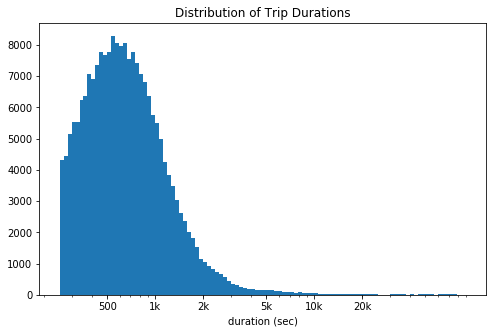

```python
# there's a long tail in the distribution, so let's put it on a log scale instead
log_binsize = 0.025
bins = 10 ** np.arange(2.4, np.log10(df_clean['duration_sec'].max())+log_binsize, log_binsize)

plt.figure(figsize=[8, 5])
plt.hist(data = df_clean, x = 'duration_sec', bins = bins)
plt.xscale('log')
plt.xticks([500, 1e3, 2e3, 5e3, 1e4, 2e4], [500, '1k', '2k', '5k', '10k', '20k'])
plt.title('Distribution of Trip Durations')
plt.xlabel('duration (sec)')
plt.show()
```

- The duration has a long-tailed distribution, the trip duration is mostly centered on values which are less than 2000 seconds with peak around 600 seconds.

Next up, the first predictor variable of interest: user_type.

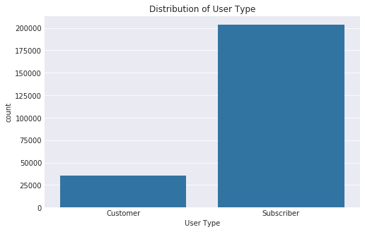

```python
plt.figure(figsize = [8,5])
sb.set_style('darkgrid')
base_color = sb.color_palette()[0]
sb.countplot(data = df_clean, x = 'user_type', color = base_color);
plt.title('Distribution of User Type');
plt.xlabel('User Type');
```

- The subscribers are much more than the customer.

I'll now move on to the other variables in the dataset: bike_share_for_all_trip.

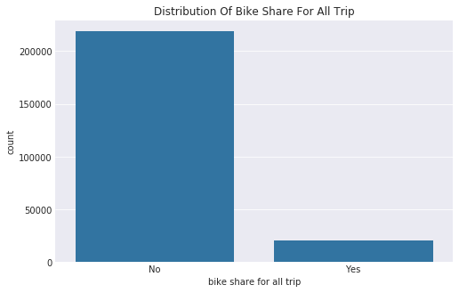

```python
plt.figure(figsize = [8,5])
sb.set_style('darkgrid')
sb.countplot(data = df_clean, x = 'bike_share_for_all_trip', color = base_color);
plt.title('Distribution Of Bike Share For All Trip');
plt.xlabel('bike share for all trip');
```

- The bike that doesn't share for all trip are much more than the bike that share.

I'll now look at the other features in the data to see if any of them hold interesting properties.

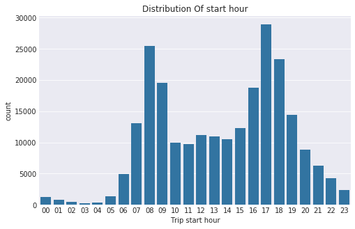

```python
plt.figure(figsize = [8,5])
sb.set_style('darkgrid')
sb.countplot(data = df_clean, x = 'start_hour', color = base_color);
plt.title('Distribution Of start hour');
plt.xlabel('Trip start hour');
```

- We noticed that there are two peak in 8 am and 5 pm.

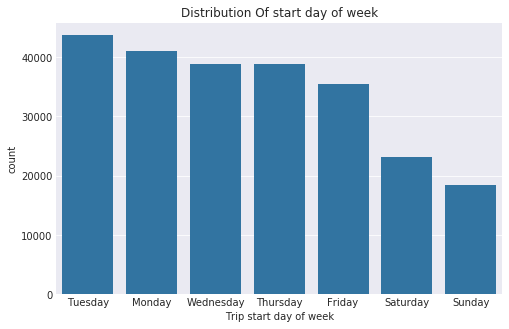

```python
plt.figure(figsize = [8,5])
sb.set_style('darkgrid')
week_order = df_clean['start_day_of_week'].value_counts().index
sb.countplot(data = df_clean, x = 'start_day_of_week', color = base_color, order = week_order);
plt.title('Distribution Of start day of week');
plt.xlabel('Trip start day of week');
```

### Discuss the distribution(s) of your variable(s) of interest. Were there any unusual points? Did you need to perform any transformations?

```
The duration variable took on a large range of values, and is concentrated at 600 seconds peak then distribution starts to dip and there is no more peak value.
```

### Of the features you investigated, were there any unusual distributions? Did you perform any operations on the data to tidy, adjust, or change the form of the data? If so, why did you do this?

```
Nothing seems out of the normal expectations
```

## Bivariate Exploration

```
In this section, I'll investigate relationships between two features.
```

#### How does the trip duration distribution vary between customers and subscribers?

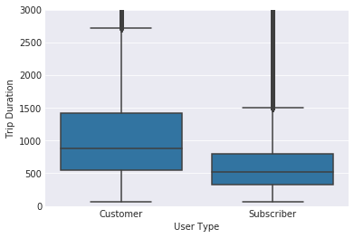

```python
# How does the trip duration distribution vary between customers and subscribers?

sb.boxplot(data=df_clean, x='user_type', y='duration_sec', color=base_color);
plt.ylim([-10, 3000])
plt.xlabel('User Type');
plt.ylabel('Trip Duration');
```

- We can noticed that the customer rides longer trips than subscriber although number of subscriber riders are very high then customer.

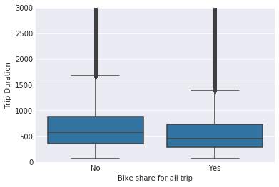

```python
# How does the trip duration distribution vary by bike_share_for_all_trip?
sb.boxplot(data=df_clean, x='bike_share_for_all_trip', y='duration_sec', color=base_color);
plt.ylim([-10, 3000])
plt.xlabel('Bike share for all trip');
plt.ylabel('Trip Duration');
```

- The bike that share for all trip rides have shorter trips

#### How does the trip duration vary on hours?

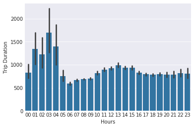

```python
# Duration on hours
sb.barplot(data=df_clean, x='start_hour', y='duration_sec', color=base_color);
plt.xlabel('Hours');
plt.ylabel('Trip Duration');
```

#### How does the trip duration vary on Weekdays?

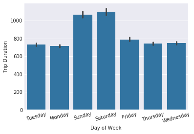

```python
# Duration on Weekdays
sb.barplot(data=df_clean, x='start_day_of_week', y='duration_sec', color=base_color);
plt.xticks(rotation = 15);
plt.xlabel('Day of Week');
plt.ylabel('Trip Duration');
```

- The riding trips are much longer on sunday and saturday, It indicates a more flexible use on weekends.

#### How the hourly usage vary between customers and subscribers

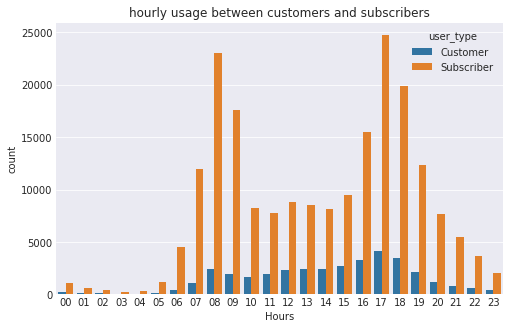

```python
# hourly usage between customers and subscribers
plt.figure(figsize = [8,5])
sb.countplot(data=df_clean, x='start_hour', hue='user_type');
plt.title('hourly usage between customers and subscribers');
plt.xlabel('Hours');
```

- We can noticed that the Subscriber usage clearly peaks out on typical rush hours when people go to work in the morning and getting off work in the afternoon, , whereas the customer had a slight difference of usage hours.

#### How the Weekly usage vary between customers and subscribers

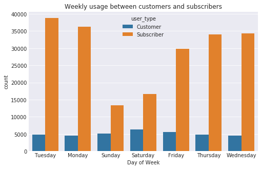

```python
# Weekly usage between customers and subscribers
plt.figure(figsize = [8,5])
sb.countplot(data=df_clean, x='start_day_of_week', hue='user_type');
plt.title('Weekly usage between customers and subscribers');
plt.xlabel('Day of Week');
```

- We can notice that the subscriber go on trip during weekdays more than weekend, whereas the customer had no much difference between weekdays and weekend.

### Talk about some of the relationships you observed in this part of the investigation. How did the feature(s) of interest vary with other features in the dataset?

```
The riding trips are much longer on weekend. And the riding habit varies a lot between subscribers and customers. The subscribers use the bike for work commnute thus most trips were on weekdays, and especially during rush hours, whereas customers tend to ride for fun on weekends.
```

## Multivariate Exploration

```
In this section, I'll investigate relationships between three or more features.
```

#### How the hourly Usage during Weekdays vary for Customer and Subscriber?

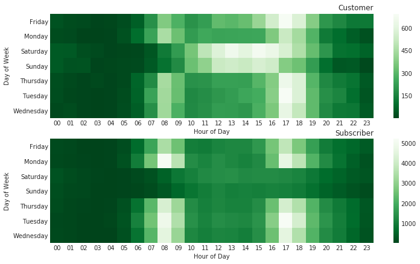

```python
# The hourly usage during weekdays for customers and subscribers?
plt.suptitle('Hourly Usage during Weekdays for Customer and Subscriber');
plt.figure(figsize = [12,7]);
plt.subplot(2, 1, 1);
customers = df_clean.query('user_type == "Customer"');
c_counts = customers.groupby(['start_day_of_week', 'start_hour']).size();
c_counts = c_counts.reset_index(name='count');
c_counts = c_counts.pivot(index='start_day_of_week', columns='start_hour', values='count');
sb.heatmap(c_counts, cmap='Greens_r');
plt.title('Customer', loc='right');
plt.xlabel('Hour of Day');
plt.ylabel('Day of Week');

plt.subplot(2, 1, 2);
subscribers = df_clean.query('user_type == "Subscriber"');
s_counts = subscribers.groupby(['start_day_of_week', 'start_hour']).size();
s_counts = s_counts.reset_index(name='count');
s_counts = s_counts.pivot(index='start_day_of_week', columns='start_hour', values='count');
sb.heatmap(s_counts, cmap='Greens_r');
plt.title('Subscriber', loc='right');
plt.xlabel('Hour of Day');
plt.ylabel('Day of Week');
```

#### How the trip duration in weekdays vary between customers and subscribers?

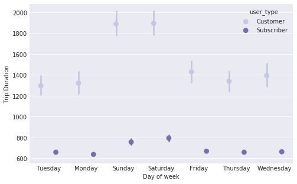

```python
# The trip duration in weekdays between customers and subscribers?
plt.figure(figsize = [8,5])
ax = sb.pointplot(data = df_clean, x='start_day_of_week', y='duration_sec', hue='user_type', palette = 'Purples', dodge=0.4, linestyles="");
plt.xlabel('Day of week');
plt.ylabel('Trip Duration');
ax.set_yticklabels([],minor = True);
```

- We can notice that the customer ride much longer than subscriber, also there is increase of trip duration on weekend

#### How the trip duration in hours vary between customers and subscribers?

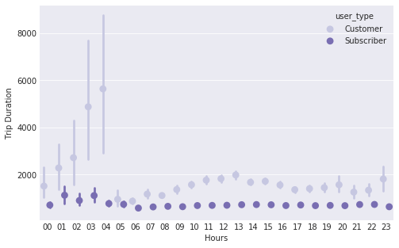

```python
# The trip duration in hours between customers and subscribers?
plt.figure(figsize = [8,5])
sb.pointplot(data = df_clean, x='start_hour', y='duration_sec', hue='user_type', palette = 'Purples', dodge=0.4, linestyles="");
plt.xlabel('Hours');
plt.ylabel('Trip Duration');
```

- Customer ride much longer than subscriber.

### Talk about some of the relationships you observed in this part of the investigation. Were there features that strengthened each other in terms of looking at your feature(s) of interest?

```
I extended my investigation of trip duration by looking at start hour and start day of week, The multivariate exploration here showed that there indeed is a positive effect of start hour and start day of week on trip duration, The efficient usage for subscribers corresponds to their high concentration on rush hours Monday through Friday, indicating the use is primarily for work commute, unlike the customers usually go on trips during weekends
```